# Credit Card Fraud Detection - EDA Report

This notebook presents an in-depth exploratory data analysis (EDA) on the Credit Card Fraud Detection dataset. We analyze feature distributions, missing values, outliers, class imbalance, and relationships between variables, with a focus on producing actionable insights.

Section: 1. Data Overview

### Purpose:

This section aims to provide an initial understanding of the dataset by inspecting its structure, feature types, and target variable distribution. Understanding data at a structural level sets the foundation for detecting data quality issues and planning appropriate preprocessing steps.

1.1 Load and Preview the Dataset

```python
# Imports
import pandas as pd
import numpy as np
import seaborn as sns
import matplotlib.pyplot as plt
import warnings
warnings.filterwarnings('ignore')

# Set Seaborn theme for clean visuals
sns.set_theme(style="whitegrid")

# Load the dataset
df = pd.read_csv("creditcard.csv")
df.head()
```

|  | Time | V1 | V2 | V3 | V4 | V5 | V6 | V7 | V8 | V9 | ... | V21 | V22 | V23 | V24 | V25 | V26 | V27 | V28 | Amount | Class |
| --- | --- | --- | --- | --- | --- | --- | --- | --- | --- | --- | --- | --- | --- | --- | --- | --- | --- | --- | --- | --- | --- |
| 0 | 0.0 | -1.359807 | -0.072781 | 2.536347 | 1.378155 | -0.338321 | 0.462388 | 0.239599 | 0.098698 | 0.363787 | ... | -0.018307 | 0.277838 | -0.110474 | 0.066928 | 0.128539 | -0.189115 | 0.133558 | -0.021053 | 149.62 | 0 |
| 1 | 0.0 | 1.191857 | 0.266151 | 0.166480 | 0.448154 | 0.060018 | -0.082361 | -0.078803 | 0.085102 | -0.255425 | ... | -0.225775 | -0.638672 | 0.101288 | -0.339846 | 0.167170 | 0.125895 | -0.008983 | 0.014724 | 2.69 | 0 |
| 2 | 1.0 | -1.358354 | -1.340163 | 1.773209 | 0.379780 | -0.503198 | 1.800499 | 0.791461 | 0.247676 | -1.514654 | ... | 0.247998 | 0.771679 | 0.909412 | -0.689281 | -0.327642 | -0.139097 | -0.055353 | -0.059752 | 378.66 | 0 |
| 3 | 1.0 | -0.966272 | -0.185226 | 1.792993 | -0.863291 | -0.010309 | 1.247203 | 0.237609 | 0.377436 | -1.387024 | ... | -0.108300 | 0.005274 | -0.190321 | -1.175575 | 0.647376 | -0.221929 | 0.062723 | 0.061458 | 123.50 | 0 |
| 4 | 2.0 | -1.158233 | 0.877737 | 1.548718 | 0.403034 | -0.407193 | 0.095921 | 0.592941 | -0.270533 | 0.817739 | ... | -0.009431 | 0.798278 | -0.137458 | 0.141267 | -0.206010 | 0.502292 | 0.219422 | 0.215153 | 69.99 | 0 |

5 rows × 31 columns

1.2 Dataset Shape and Data Types

```python
print(f"Dataset contains {df.shape[0]:,} rows and {df.shape[1]} columns.")

# Data types of each column
df.dtypes.value_counts()
df.info()
```

```
Dataset contains 284,807 rows and 31 columns.
<class 'pandas.core.frame.DataFrame'>
RangeIndex: 284807 entries, 0 to 284806
Data columns (total 31 columns):
 #   Column  Non-Null Count   Dtype
---  ------  --------------   -----
 0   Time    284807 non-null  float64
 1   V1      284807 non-null  float64
 2   V2      284807 non-null  float64
 3   V3      284807 non-null  float64
 4   V4      284807 non-null  float64
 5   V5      284807 non-null  float64
 6   V6      284807 non-null  float64
 7   V7      284807 non-null  float64
 8   V8      284807 non-null  float64
```

[output cut: 24 more lines]

### Feature Overview

The dataset contains 31 columns:

- **Time**: Seconds elapsed between this transaction and the first transaction in the dataset
- **V1–V28**: Principal components obtained with PCA (anonymized)
- **Amount**: Transaction amount
- **Class**: Target variable (0 = Not Fraud, 1 = Fraud)

1.4 Target Variable Distribution

```python
class_counts = df['Class'].value_counts()
class_percent = df['Class'].value_counts(normalize=True) * 100

pd.DataFrame({
    "Count": class_counts,
    "Percentage (%)": class_percent.round(4)
})
```

| Class | Count | Percentage (%) |
| --- | --- | --- |
| 0 | 284315 | 99.8273 |
| 1 | 492 | 0.1727 |

1.5 Visualize the Class Distribution

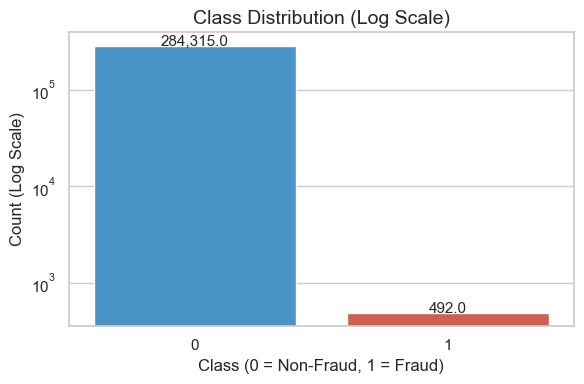

```python
plt.figure(figsize=(6, 4))
ax = sns.countplot(data=df, x='Class', palette=['#3498db', '#e74c3c'])
plt.yscale("log")
plt.title('Class Distribution (Log Scale)', fontsize=14)
plt.xlabel('Class (0 = Non-Fraud, 1 = Fraud)')
plt.ylabel('Count (Log Scale)')

for p in ax.patches:
    count = p.get_height()
    ax.text(p.get_x() + p.get_width()/2., count, f'{count:,}', ha="center", fontsize=11)

plt.tight_layout()
plt.show()
```

### Summary of Data Overview

- The dataset contains **284,807 transactions** across **31 columns**.
- All features are **numerical**, with V1–V28 being anonymized PCA features.
- The `Class` variable is **highly imbalanced**:
  - ~99.83% non-fraud (Class = 0)
  - ~0.17% fraud (Class = 1)
- This imbalance will significantly impact model evaluation and requires tailored strategies

Section: 2. Missing Values Analysis

### Purpose:

This section checks for any missing or null values in the dataset. Even in pre-cleaned datasets, confirming the absence of missing data is a critical data quality step. Visualizing the null patterns can also reveal structural issues (like entire empty columns) or potential input errors.

2.1 Check for Missing Values

```python
missing_counts = df.isnull().sum()

missing_percent = (missing_counts / df.shape[0]) * 100

missing_df = pd.DataFrame({
    'Missing Values': missing_counts,
    'Percentage (%)': missing_percent.round(4)
}).sort_values(by='Missing Values', ascending=False)

missing_df.head(10)
```

|  | Missing Values | Percentage (%) |
| --- | --- | --- |
| Time | 0 | 0.0 |
| V1 | 0 | 0.0 |
| V2 | 0 | 0.0 |
| V3 | 0 | 0.0 |
| V4 | 0 | 0.0 |
| V5 | 0 | 0.0 |
| V6 | 0 | 0.0 |
| V7 | 0 | 0.0 |
| V8 | 0 | 0.0 |
| V9 | 0 | 0.0 |

2.2 Visualize Missing Values

```python
if missing_counts.sum() > 0:
    plt.figure(figsize=(10, 5))
    sns.barplot(
        x=missing_df.index,
        y=missing_df['Missing Values'],
        palette='Reds_r'
    )
    plt.xticks(rotation=90)
    plt.title('Missing Values Per Feature')
    plt.ylabel('Count')
    plt.tight_layout()
    plt.show()
else:
    print("No missing values detected in the dataset.")
```

```
No missing values detected in the dataset.
```